# FinalProject_bankruptcy_Danyah_Khan

### Polish Bankruptcy dataset - Danyah Khan

The overall problem we are trying to solve is whether we can use the finances of a company to predict whether a company is at risk of going bankrupt. This is important for companies that want to know the future of their company. They might have been successful at one point, but have hit a turning point for the worse and are trying to figure out if their company is too much in losses and will go bankrupt. The solution is valuable because the company can be prepared to go bankrupt or they can take a risk and work towards getting their company out of bankruptcy.

Reducing costs increases profitability, but only if sales prices and number of sales remain constant. However, if a company can efficiently cut costs without affecting quality, sales price, or sales figures, then that provides a path to higher profitability (Maverick 2020)

I'm answering the following research question, can the sales and costs be used for evaluating the company's profitability in that year? So, we will examine the features related to sales and costs compared to the orginal.

Also, my runtime for the grid search was really high and there were some errors with the memory allocation, so I had to manually test out different hyperparameters. Research: https://www.investopedia.com/ask/answers/122214/company-it-more-important-lower-costs-or-increase-revenue.asp#:~:text=Impact%20of%20Reducing%20Costs,number%20of%20sales%20remain%20constant.&text=However%2C%20if%20a%20company%20can,a%20path%20to%20higher%20profitability.

```python
import sklearn
sklearn.__version__
```

```
'0.22.1'
```

```python
from sklearn.model_selection import train_test_split
from sklearn import metrics

import matplotlib.pyplot as plt

import pandas as pd
import numpy as np
import seaborn as sns
```

```python
pd.set_option('display.max_columns', 100)
```

```python
#bank = pd.read_csv(r"C:\Users\danya\OneDrive\Desktop\\Full_dataset_bankruptcy.csv")

url = "https://raw.githubusercontent.com/jessefranks/DSC-540-Project/main/Full_dataset_bankruptcy.csv"# I've upload our data to github so we dont have to mount the file.
df = pd.read_csv(url, na_values="?")
```

```python
df.shape
```

```
(43405, 65)
```

```python
df.isnull().sum()
```

```
net profit / total assets                    8
total liabilities / total assets             8
working capital / total assets               8
current assets / short-term liabilities    134
X5                                          89
                                          ...
sales / receivables                        102
(short-term liabilities *365) / sales      127
sales / short-term liabilities             134
sales / fixed assets                       812
Target                                       0
Length: 65, dtype: int64
```

```python
df = df.fillna(df.mean())
```

```python
df.shape
```

```
(43405, 65)
```

```python
df.isnull().sum()
```

```
net profit / total assets                  0
total liabilities / total assets           0
working capital / total assets             0
current assets / short-term liabilities    0
X5                                         0
                                          ..
sales / receivables                        0
(short-term liabilities *365) / sales      0
sales / short-term liabilities             0
sales / fixed assets                       0
Target                                     0
Length: 65, dtype: int64
```

To clean the data, for the null values, I took the mean of the values in the column and subsituted that in for the null values.

### Exploratory Data Analysis

```python
df.describe()
```

|  | net profit / total assets | total liabilities / total assets | working capital / total assets | current assets / short-term liabilities | X5 | retained earnings / total assets | EBIT / total assets | book value of equity / total liabilities | sales / total assets | equity / total assets | X11 | gross profit / short-term liabilities | (gross profit + depreciation) / sales | (gross profit + interest) / total assets | (total liabilities * 365) / (gross profit + depreciation) | (gross profit + depreciation) / total liabilities | total assets / total liabilities | gross profit / total assets | gross profit / sales | (inventory * 365) / sales | sales (n) / sales (n-1) | profit on operating activities / total assets | net profit / sales | gross profit (in 3 years) / total assets | (equity - share capital) / total assets | (net profit + depreciation) / total liabilities | profit on operating activities / financial expenses | working capital / fixed assets | logarithm of total assets | … |
| --- | --- | --- | --- | --- | --- | --- | --- | --- | --- | --- | --- | --- | --- | --- | --- | --- | --- | --- | --- | --- | --- | --- | --- | --- | --- | --- | --- | --- | --- | --- |
| count | 43405.000000 | 43405.000000 | 43405.000000 | 43405.000000 | 4.340500e+04 | 43405.000000 | 43405.000000 | 43405.000000 | 43405.000000 | 43405.000000 | 43405.000000 | 43405.000000 | 43405.000000 | 43405.000000 | 4.340500e+04 | 43405.000000 | 43405.000000 | 43405.000000 | 43405.000000 | 4.340500e+04 | 43405.000000 | 43405.000000 | 43405.000000 | 43405.000000 | 43405.000000 | 43405.000000 | 4.340500e+04 | 43405.000000 | 43405.000000 | … |
| mean | 0.035160 | 0.590212 | 0.114431 | 6.314702 | -3.853466e+02 | -0.056107 | 0.093478 | 12.640779 | 2.652166 | 0.626868 | 0.131075 | 1.132430 | 0.809544 | 0.093489 | 1.991890e+03 | 1.411167 | 13.802535 | 0.098565 | 0.156277 | 2.430209e+02 | 3.884997 | 0.113923 | 0.138582 | 0.270012 | 0.392844 | 1.263864 | 1.107896e+03 | 6.003208 | 4.005020 | … |
| std | 2.993833 | 5.842209 | 5.438928 | 294.978029 | 6.118020e+04 | 7.200663 | 5.712548 | 505.346176 | 62.926207 | 14.669245 | 5.304091 | 67.485881 | 86.816761 | 5.712548 | 9.639193e+04 | 68.444971 | 506.772450 | 5.737116 | 48.620304 | 3.749021e+04 | 212.690090 | 5.155303 | 48.264208 | 7.902852 | 12.890251 | 66.151611 | 3.387922e+04 | 152.026308 | 0.826781 | … |
| min | -463.890000 | -430.870000 | -479.960000 | -0.403110 | -1.190300e+07 | -508.410000 | -517.480000 | -141.410000 | -3.496000 | -479.910000 | -463.890000 | -6331.800000 | -1460.600000 | -517.480000 | -9.632400e+06 | -6331.800000 | -0.412920 | -517.480000 | -1578.700000 | -2.934000e+01 | -1325.000000 | -431.590000 | -1578.700000 | -463.890000 | -500.930000 | -6331.800000 | -2.590100e+05 | -3829.900000 | -0.886060 | … |
| 25% | 0.003434 | 0.269010 | 0.021540 | 1.050800 | -4.949000e+01 | 0.000000 | 0.005783 | 0.431070 | 1.018500 | 0.295530 | 0.015466 | 0.015294 | 0.023998 | 0.005795 | 2.231800e+02 | 0.073787 | 1.452400 | 0.005795 | 0.003947 | 1.544900e+01 | 0.934070 | 0.000000 | 0.002329 | 0.024308 | 0.150140 | 0.067034 | 1.062800e-01 | 0.044774 | 3.495300 | … |
| 50% | 0.049636 | 0.471940 | 0.196580 | 1.574000 | -1.184000e+00 | 0.000000 | 0.059653 | 1.074100 | 1.195500 | 0.505990 | 0.075444 | 0.173830 | 0.068794 | 0.059665 | 8.471100e+02 | 0.246780 | 2.119000 | 0.059665 | 0.036180 | 3.528400e+01 | 1.086800 | 0.062273 | 0.030139 | 0.161710 | 0.384600 | 0.222550 | 1.278200e+00 | 0.486640 | 4.013900 | … |
| 75% | 0.129560 | 0.688270 | 0.403260 | 2.806000 | 5.046100e+01 | 0.089441 | 0.150810 | 2.639100 | 2.063000 | 0.709090 | 0.166590 | 0.593420 | 0.135830 | 0.150830 | 2.224800e+03 | 0.669140 | 3.717800 | 0.150880 | 0.091700 | 6.407300e+01 | 1.346100 | 0.149940 | 0.078777 | 0.350270 | 0.610700 | 0.602580 | 8.273500e+00 | 1.618100 | 4.520100 | … |
| max | 94.280000 | 480.960000 | 28.336000 | 53433.000000 | 1.250100e+06 | 543.250000 | 649.230000 | 53432.000000 | 9742.300000 | 1099.500000 | 681.540000 | 8259.400000 | 13315.000000 | 649.230000 | 1.023600e+07 | 8259.400000 | 53433.000000 | 649.230000 | 9230.500000 | 7.809200e+06 | 29907.000000 | 681.540000 | 9230.500000 | 831.660000 | 1353.300000 | 8262.300000 | 4.208800e+06 | 21701.000000 | 9.698300 | … |

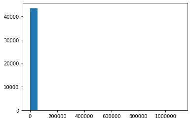

```python
# create a histogram for total costs /total sales
plt.hist(x = df['total costs /total sales'], bins = 20)
plt.show()
```

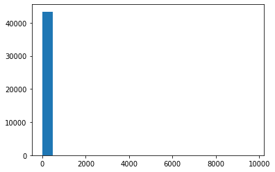

```python
# create a histogram for sales / total assets
plt.hist(x = df['sales / total assets'], bins = 20)
plt.show()
```

[output not shown]

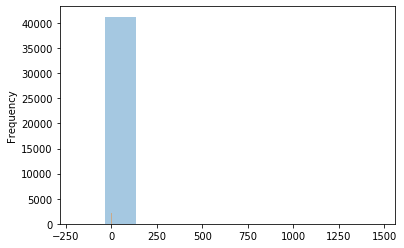

```python
hist = df[df['total costs /total sales'] < 1600]

hist.groupby('Target')['total costs /total sales'].plot(kind='hist', alpha=0.4, bins = 10)
```

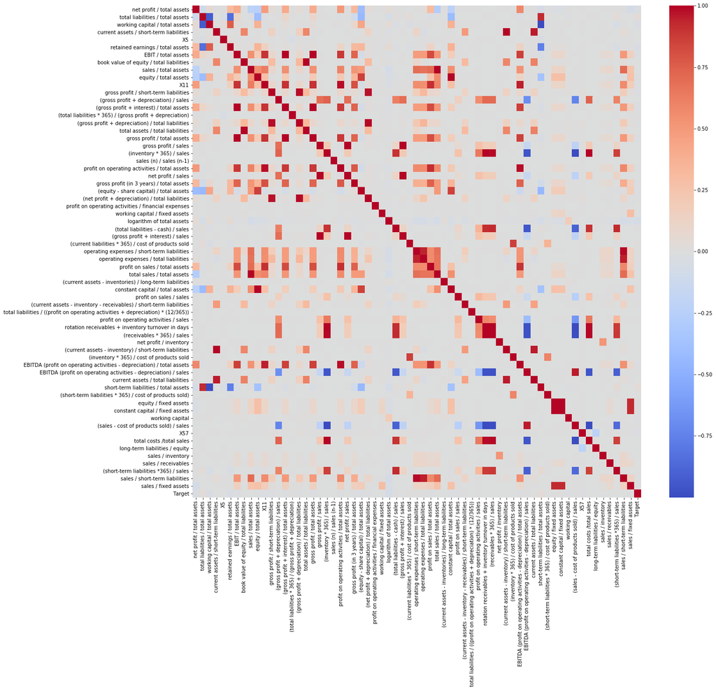

```python
corr = df.corr()
f, ax = plt.subplots(figsize=(20, 18))
sns.heatmap(corr, cmap="coolwarm")
plt.show()
```

### Machine Learning Techniques on entire scaled model

```python
X = df.drop('Target', axis=1)
y = df.Target
```

```python
X.head()
```

|  | net profit / total assets | total liabilities / total assets | working capital / total assets | current assets / short-term liabilities | X5 | retained earnings / total assets | EBIT / total assets | book value of equity / total liabilities | sales / total assets | equity / total assets | X11 | gross profit / short-term liabilities | (gross profit + depreciation) / sales | (gross profit + interest) / total assets | (total liabilities * 365) / (gross profit + depreciation) | (gross profit + depreciation) / total liabilities | total assets / total liabilities | gross profit / total assets | gross profit / sales | (inventory * 365) / sales | sales (n) / sales (n-1) | profit on operating activities / total assets | net profit / sales | gross profit (in 3 years) / total assets | (equity - share capital) / total assets | (net profit + depreciation) / total liabilities | profit on operating activities / financial expenses | working capital / fixed assets | logarithm of total assets | … |
| --- | --- | --- | --- | --- | --- | --- | --- | --- | --- | --- | --- | --- | --- | --- | --- | --- | --- | --- | --- | --- | --- | --- | --- | --- | --- | --- | --- | --- | --- | --- |
| 0 | 0.200550 | 0.37951 | 0.39641 | 2.0472 | 32.3510 | 0.38825 | 0.249760 | 1.33050 | 1.1389 | 0.50494 | 0.249760 | 0.65980 | 0.166600 | 0.249760 | 497.42 | 0.73378 | 2.6349 | 0.249760 | 0.149420 | 43.370 | 1.247900 | 0.21402 | 0.119980 | 0.477060 | 0.50494 | 0.60411 | 1.45820 | 1.7615 | 5.9443 | … |
| 1 | 0.209120 | 0.49988 | 0.47225 | 1.9447 | 14.7860 | 0.00000 | 0.258340 | 0.99601 | 1.6996 | 0.49788 | 0.261140 | 0.51680 | 0.158350 | 0.258340 | 677.96 | 0.53838 | 2.0005 | 0.258340 | 0.152000 | 87.981 | 1.429300 | 0.24806 | 0.123040 | 0.270012 | 0.39542 | 0.43992 | 88.44400 | 16.9460 | 3.6884 | … |
| 2 | 0.248660 | 0.69592 | 0.26713 | 1.5548 | -1.1523 | 0.00000 | 0.309060 | 0.43695 | 1.3090 | 0.30408 | 0.312580 | 0.64184 | 0.244350 | 0.309060 | 794.16 | 0.45961 | 1.4369 | 0.309060 | 0.236100 | 73.133 | 1.428300 | 0.30260 | 0.189960 | 0.270012 | 0.28932 | 0.37282 | 86.01100 | 1.0627 | 4.3749 | … |
| 3 | 0.081483 | 0.30734 | 0.45879 | 2.4928 | 51.9520 | 0.14988 | 0.092704 | 1.86610 | 1.0571 | 0.57353 | 0.092704 | 0.30163 | 0.094257 | 0.092704 | 917.01 | 0.39803 | 3.2537 | 0.092704 | 0.071428 | 79.788 | 1.506900 | 0.11550 | 0.062782 | 0.171930 | 0.57353 | 0.36152 | 0.94076 | 1.9618 | 4.6511 | … |
| 4 | 0.187320 | 0.61323 | 0.22960 | 1.4063 | -7.3128 | 0.18732 | 0.187320 | 0.63070 | 1.1559 | 0.38677 | 0.187320 | 0.33147 | 0.121820 | 0.187320 | 1133.20 | 0.32211 | 1.6307 | 0.187320 | 0.115530 | 57.045 | 3.884997 | 0.19832 | 0.115530 | 0.187320 | 0.38677 | 0.32211 | 1.41380 | 1.1184 | 4.1424 | … |

```python
y.head()
```

```
0    0
1    0
2    0
3    0
4    0
Name: Target, dtype: int64
```

```python
from sklearn.model_selection import train_test_split
X_train, X_test, y_train, y_test = train_test_split(X, y, test_size = 0.20, random_state= 2021)
X_train, X_val, y_train, y_val = train_test_split(X_train, y_train, test_size=0.20, random_state=2021)
```

```python
# Standardization of the data
from sklearn.preprocessing import StandardScaler
ss = StandardScaler()
ss.fit(X_train)
X_train = ss.transform(X_train)
X_val = ss.transform(X_val)
X_test = ss.transform(X_test)
```

```python
X_train.shape
```

```
(27779, 64)
```

```python
X_val.shape
```

```
(6945, 64)
```

```python
X_test.shape
```

```
(8681, 64)
```

### applying logistic regression

```python
from sklearn.linear_model import LogisticRegression
from sklearn import metrics
from sklearn.metrics import balanced_accuracy_score
```

```python
clf = LogisticRegression(penalty='l2', dual=False, tol=0.0001, C=1.0, fit_intercept=True, intercept_scaling=1,
                        class_weight=None, random_state=None, solver='saga', max_iter=1000)

clf.fit(X_train, y_train)
```

```
LogisticRegression(C=1.0, class_weight=None, dual=False, fit_intercept=True,
                   intercept_scaling=1, l1_ratio=None, max_iter=1000,
                   multi_class='auto', n_jobs=None, penalty='l2',
                   random_state=None, solver='saga', tol=0.0001, verbose=0,
                   warm_start=False)
```

```python
pred = clf.predict(X_train)
print("Train set balanced accuracy:  " + str(metrics.balanced_accuracy_score(y_true = y_train, y_pred = pred)))
print("Train set R^2 score: " + str(metrics.r2_score(y_true = y_train, y_pred = pred)))
print("Train set RMSE:      " + str(np.sqrt(metrics.mean_squared_error(y_true = y_train, y_pred = pred))))
print(' ')
pred = clf.predict(X_val)
print("Train set balanced accuracy:  " + str(metrics.balanced_accuracy_score(y_true = y_val, y_pred = pred)))
print("Train set R^2 score: " + str(metrics.r2_score(y_true = y_val, y_pred = pred)))
print("Train set RMSE:      " + str(np.sqrt(metrics.mean_squared_error(y_true = y_val, y_pred = pred))))

print(' ')

pred = clf.predict(X_test)
print("Test set balanced accuracy:   " + str(metrics.balanced_accuracy_score(y_true = y_test, y_pred =pred )))
print("Test set R^2 score:  " + str(metrics.r2_score(y_true = y_test, y_pred = pred)))
print("Test set RMSE:       " + str(np.sqrt(metrics.mean_squared_error(y_true = y_test, y_pred = pred))))
```

```
Train set balanced accuracy:  0.5025361206932514
Train set R^2 score: -0.049133390048896386
Train set RMSE:      0.21798602985511403

Train set balanced accuracy:  0.5014450867052023
Train set R^2 score: -0.04939047517271389
Train set RMSE:      0.22288119238268303

Test set balanced accuracy:   0.5011792452830188
Test set R^2 score:  -0.048870769455762186
Test set RMSE:       0.22074216899408952
```

```python
pred = clf.predict(X_train)
print("Train set balanced accuracy:  " + str(balanced_accuracy_score(y_true = y_train, y_pred = pred)))

pred = clf.predict(X_val)
print("Validation set balanced accuracy:  " + str(balanced_accuracy_score(y_true = y_val, y_pred = pred)))

pred = clf.predict(X_test)
print("Test set balanced accuracy:   " + str(balanced_accuracy_score(y_true = y_test, y_pred =pred )))
```

```
Train set balanced accuracy:  0.5025361206932514
Validation set balanced accuracy:  0.5014450867052023
Test set balanced accuracy:   0.5011792452830188
```

The logistic regression has a very low balanced accuracy, so there is likely another model that should be used.

### knn classifier

```python
from sklearn.neighbors import KNeighborsClassifier
```

```python
clf = KNeighborsClassifier(n_neighbors = 6)
clf.fit(X_train, y_train)

pred = clf.predict(X_train)
```

```python
pred = clf.predict(X_train)
print("Train set accuracy:  " + str(metrics.balanced_accuracy_score(y_true = y_train, y_pred = pred)))

pred = clf.predict(X_val)
print("Test set accuracy:   " + str(metrics.balanced_accuracy_score(y_true = y_val, y_pred =pred )))

pred = clf.predict(X_test)
print("Test set accuracy:   " + str(metrics.balanced_accuracy_score(y_true = y_test, y_pred =pred )))
```

```
Train set accuracy:  0.5160676721919802
Test set accuracy:   0.5022082519071466
Test set accuracy:   0.5067121436128522
```

```python
print("This is the classification report and confusion matrix of the test set.")
print(metrics.classification_report(y_test, pred))
print(metrics.confusion_matrix(y_true = y_test, y_pred = pred))
```

```
This is the classification report and confusion matrix of the test set.
              precision    recall  f1-score   support

           0       0.95      1.00      0.97      8257
           1       0.50      0.01      0.03       424

    accuracy                           0.95      8681
   macro avg       0.73      0.51      0.50      8681
weighted avg       0.93      0.95      0.93      8681

[[8251    6]
 [ 418    6]]
```

There was no improvement in the knn classifier model.

### Decision Tree model on entire data

```python
from sklearn.tree import DecisionTreeClassifier
```

```python
dtc = DecisionTreeClassifier(max_depth = 6, min_samples_split = 7, min_samples_leaf = 5)
```

```python
dtc.fit(X_train, y_train)

pred = dtc.predict(X_test)
```

```python
print("This is the classification report and confusion matrix of the test set.")
print(metrics.classification_report(y_test, pred))
print(metrics.confusion_matrix(y_true = y_test, y_pred = pred))
```

```
This is the classification report and confusion matrix of the test set.
              precision    recall  f1-score   support

           0       0.97      1.00      0.98      8257
           1       0.95      0.38      0.54       424

    accuracy                           0.97      8681
   macro avg       0.96      0.69      0.76      8681
weighted avg       0.97      0.97      0.96      8681

[[8249    8]
 [ 265  159]]
```

```python
pred = dtc.predict(X_train)
print("Train set balanced accuracy:  " + str(balanced_accuracy_score(y_true = y_train, y_pred = pred)))

pred = dtc.predict(X_val)
print("Validation set balanced accuracy:  " + str(balanced_accuracy_score(y_true = y_val, y_pred = pred)))

pred = dtc.predict(X_test)
print("Test set balanced accuracy:   " + str(balanced_accuracy_score(y_true = y_test, y_pred =pred )))
```

```
Train set balanced accuracy:  0.7032934491350151
Validation set balanced accuracy:  0.6989673509824137
Test set balanced accuracy:   0.6870155625529853
```

### Adaboost model

```python
from sklearn.ensemble import AdaBoostClassifier
```

```python
clf = AdaBoostClassifier(n_estimators = 200, learning_rate = 0.9)
clf.fit(X_train, y_train)
```

```
AdaBoostClassifier(algorithm='SAMME.R', base_estimator=None, learning_rate=0.9,
                   n_estimators=200, random_state=None)
```

```python
pred = clf.predict(X_train)
print("Train set balanced accuracy:  " + str(balanced_accuracy_score(y_true = y_train, y_pred = pred)))

pred = clf.predict(X_val)
print("Validation set balanced accuracy:  " + str(balanced_accuracy_score(y_true = y_val, y_pred = pred)))

pred = clf.predict(X_test)
print("Test set balanced accuracy:   " + str(balanced_accuracy_score(y_true = y_test, y_pred =pred )))
```

```
Train set balanced accuracy:  0.6270295474655416
Validation set balanced accuracy:  0.6220856286685581
Test set balanced accuracy:   0.6261442549603424
```

```python
print("This is the classification report and confusion matrix of the test set.")
print(metrics.classification_report(y_test, pred))
print(metrics.confusion_matrix(y_true = y_test, y_pred = pred))
```

```
This is the classification report and confusion matrix of the test set.
              precision    recall  f1-score   support

           0       0.96      0.99      0.98      8257
           1       0.65      0.26      0.37       424

    accuracy                           0.96      8681
   macro avg       0.81      0.63      0.67      8681
weighted avg       0.95      0.96      0.95      8681

[[8198   59]
 [ 314  110]]
```

The adaboost model performed much worse than the decision tree as can be seen from the balanced accuracy, the confusion matrix also shows that there are many false positives and negatives.

### Gradient Boost

```python
from sklearn.ensemble import GradientBoostingClassifier
```

```python
clf = GradientBoostingClassifier(n_estimators = 100, learning_rate = 0.4)
clf.fit(X_train, y_train)
```

[output not shown]

```python
print("This is the classification report and confusion matrix of the test set.")
print(metrics.classification_report(y_test, pred))
print(metrics.confusion_matrix(y_true = y_test, y_pred = pred))
```

[output not shown]

```python
pred = clf.predict(X_train)
print("Train set balanced accuracy:  " + str(balanced_accuracy_score(y_true = y_train, y_pred = pred)))

pred = clf.predict(X_val)
print("Validation set balanced accuracy:  " + str(balanced_accuracy_score(y_true = y_val, y_pred = pred)))

pred = clf.predict(X_test)
print("Test set balanced accuracy:   " + str(balanced_accuracy_score(y_true = y_test, y_pred =pred )))
```

```
Train set balanced accuracy:  0.7237892040798354
Validation set balanced accuracy:  0.7069559497103695
Test set balanced accuracy:   0.7117191588155047
```

### Creating the filtered data with attributes related to sales and cost

```python
url = "https://raw.githubusercontent.com/jessefranks/DSC-540-Project/main/Full_dataset_bankruptcy.csv"# I've upload our data to github so we dont have to mount the file.
df = pd.read_csv(url, na_values="?")
df = df.fillna(df.mean())
```

```python
df = df[["sales / total assets", "(gross profit + depreciation) / sales",
                    "gross profit / sales", "(inventory * 365) / sales",
                    "sales (n) / sales (n-1)", "net profit / sales",
                    "(total liabilities - cash) / sales", "(gross profit + interest) / sales",
                    "profit on sales / total assets", "profit on sales / sales",
                    "profit on operating activities / sales", "(receivables * 365) / sales",
                    "EBITDA (profit on operating activities - depreciation) / sales",
                    "(short-term liabilities * 365) / cost of products sold)",
                    "(sales - cost of products sold) / sales",
                    "total costs /total sales", "sales / inventory", "sales / receivables",
                    "(short-term liabilities *365) / sales",
                    "sales / short-term liabilities", "sales / fixed assets", "Target"]]
```

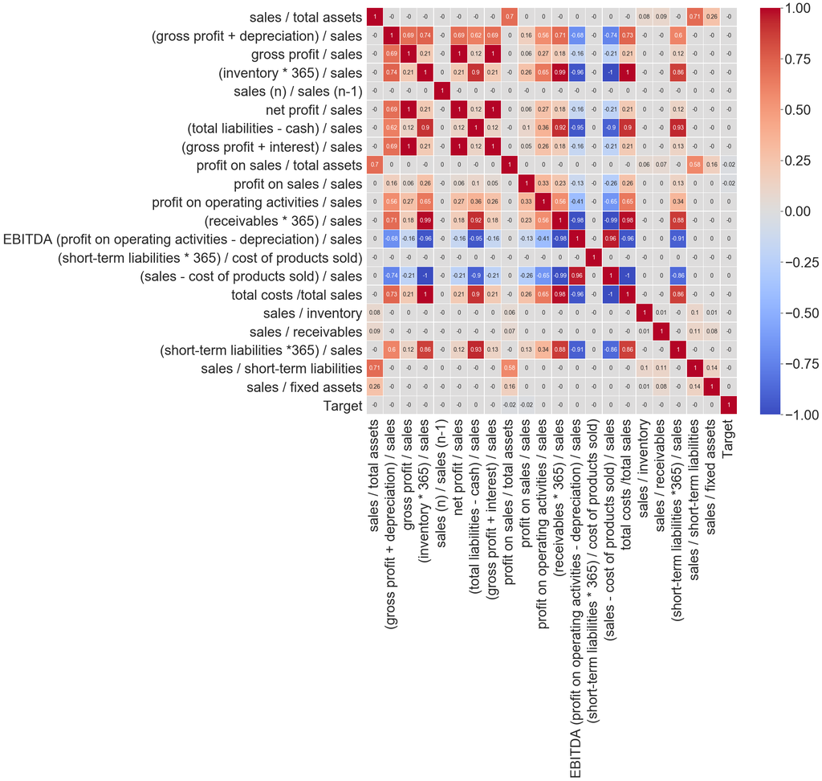

```python
corr = df.corr()
f, ax = plt.subplots(figsize=(20, 18))
sns.heatmap(round(corr,2), annot=True, ax=ax, cmap="coolwarm", linewidths=.5,  annot_kws={"size": 14})
plt.show()
t= f.suptitle('Sales and Costs Correlation Heatmap', fontsize=20)
sns.set(font_scale=1.8)
```

```python
import matplotlib.pyplot as plt
import pandas as pd
```

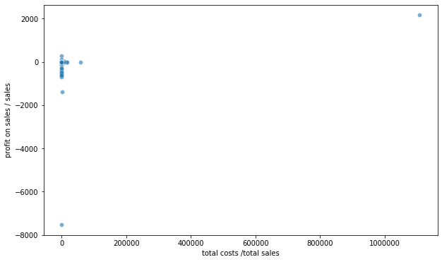

```python
fig, ax = plt.subplots(figsize=(10, 6))
ax.scatter(x = df['total costs /total sales'], y = df['profit on sales / sales'], edgecolors = "white", linewidths = 0.4, alpha = 0.6)
plt.xlabel("total costs /total sales")
plt.ylabel("profit on sales / sales")

plt.show()
```

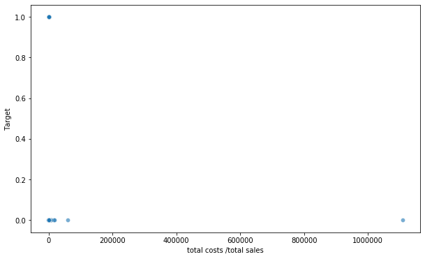

```python
fig, ax = plt.subplots(figsize=(10, 6))
ax.scatter(x = df['total costs /total sales'], y = df['Target'], edgecolors = "white", linewidths = 0.4, alpha = 0.6)
plt.xlabel("total costs /total sales")
plt.ylabel("Target")

plt.show()
```

```python
df.describe()
```

|  | sales / total assets | (gross profit + depreciation) / sales | gross profit / sales | (inventory * 365) / sales | sales (n) / sales (n-1) | net profit / sales | (total liabilities - cash) / sales | (gross profit + interest) / sales | profit on sales / total assets | profit on sales / sales | profit on operating activities / sales | (receivables * 365) / sales | EBITDA (profit on operating activities - depreciation) / sales | (short-term liabilities * 365) / cost of products sold) | (sales - cost of products sold) / sales | total costs /total sales | sales / inventory | sales / receivables | (short-term liabilities *365) / sales | sales / short-term liabilities | sales / fixed assets | Target |
| --- | --- | --- | --- | --- | --- | --- | --- | --- | --- | --- | --- | --- | --- | --- | --- | --- | --- | --- | --- | --- | --- | --- |
| count | 43405.000000 | 43405.000000 | 43405.000000 | 4.340500e+04 | 43405.000000 | 43405.000000 | 43405.000000 | 43405.000000 | 43405.000000 | 43405.000000 | 43405.000000 | 4.340500e+04 | 43405.000000 | 43405.000000 | 4.340500e+04 | 4.340500e+04 | 4.340500e+04 | 43405.000000 | 4.340500e+04 | 43405.000000 | 43405.000000 | 43405.000000 |
| mean | 2.652166 | 0.809544 | 0.156277 | 2.430209e+02 | 3.884997 | 0.138582 | 7.370821 | 0.176847 | 0.111908 | -0.289102 | -0.142514 | 8.311085e+02 | -0.482584 | 6.478459 | -2.621959e+01 | 3.002644e+01 | 4.480858e+02 | 17.033202 | 1.502328e+03 | 9.343074 | 72.788592 | 0.048174 |
| std | 62.926207 | 86.816761 | 48.620304 | 3.749021e+04 | 212.690090 | 48.264208 | 813.297607 | 48.677039 | 4.782957 | 39.198886 | 15.967576 | 1.098898e+05 | 45.086068 | 637.664847 | 5.320062e+03 | 5.329289e+03 | 3.153355e+04 | 552.399187 | 1.390628e+05 | 123.985521 | 2347.072100 | 0.214137 |
| min | -3.496000 | -1460.600000 | -1578.700000 | -2.934000e+01 | -1325.000000 | -1578.700000 | -6351.700000 | -1495.600000 | -431.590000 | -7522.000000 | -1395.800000 | -1.158700e+05 | -9001.000000 | -25.467000 | -1.108300e+06 | -1.986900e+02 | -1.244000e+01 | -12.656000 | -2.336500e+06 | -1.543200 | -10677.000000 | 0.000000 |
| 25% | 1.018500 | 0.023998 | 0.003947 | 1.544900e+01 | 0.934070 | 0.002329 | 0.083115 | 0.007062 | 0.006052 | 0.003907 | 0.000000 | 3.493800e+01 | -0.027299 | 0.127380 | 8.959000e-03 | 8.755400e-01 | 5.729400e+00 | 4.515600 | 4.220500e+01 | 3.100200 | 2.207800 | 0.000000 |
| 50% | 1.195500 | 0.068794 | 0.036180 | 3.528400e+01 | 1.086800 | 0.030139 | 0.218200 | 0.043350 | 0.060684 | 0.036652 | 0.037770 | 5.488100e+01 | 0.010755 | 0.215770 | 5.270100e-02 | 9.511200e-01 | 1.040000e+01 | 6.649500 | 7.153500e+01 | 5.102900 | 4.389200 | 0.000000 |
| 75% | 2.063000 | 0.135830 | 0.091700 | 6.407300e+01 | 1.346100 | 0.078777 | 0.411340 | 0.102220 | 0.150070 | 0.091532 | 0.091865 | 8.082000e+01 | 0.062055 | 0.354540 | 1.287800e-01 | 9.928000e-01 | 2.389000e+01 | 10.443000 | 1.177400e+02 | 8.650900 | 10.461000 | 0.000000 |
| max | 9742.300000 | 13315.000000 | 9230.500000 | 7.809200e+06 | 29907.000000 | 9230.500000 | 152860.000000 | 9244.300000 | 626.920000 | 2156.500000 | 2156.800000 | 2.258400e+07 | 178.890000 | 88433.000000 | 2.931500e+02 | 1.108300e+06 | 4.818700e+06 | 108000.000000 | 2.501600e+07 | 23454.000000 | 294770.000000 | 1.000000 |

```python
X = df.drop('Target', axis=1)
y = df.Target
```

```python
X.head()
```

|  | sales / total assets | (gross profit + depreciation) / sales | gross profit / sales | (inventory * 365) / sales | sales (n) / sales (n-1) | net profit / sales | (total liabilities - cash) / sales | (gross profit + interest) / sales | profit on sales / total assets | profit on sales / sales | profit on operating activities / sales | (receivables * 365) / sales | EBITDA (profit on operating activities - depreciation) / sales | (short-term liabilities * 365) / cost of products sold) | (sales - cost of products sold) / sales | total costs /total sales | sales / inventory | sales / receivables | (short-term liabilities *365) / sales | sales / short-term liabilities | sales / fixed assets |
| --- | --- | --- | --- | --- | --- | --- | --- | --- | --- | --- | --- | --- | --- | --- | --- | --- | --- | --- | --- | --- | --- |
| 0 | 1.1389 | 0.166600 | 0.149420 | 43.370 | 1.247900 | 0.119980 | 0.11788 | 0.149420 | 0.21402 | 0.128040 | 0.128040 | 71.050 | 0.110850 | 0.25792 | 0.121960 | 0.87804 | 8.4160 | 5.1372 | 82.658 | 4.4158 | 7.4277 |
| 1 | 1.6996 | 0.158350 | 0.152000 | 87.981 | 1.429300 | 0.123040 | 0.26969 | 0.152000 | 0.20616 | 0.121300 | 0.145950 | 111.510 | 0.139610 | 0.33472 | 0.121300 | 0.85300 | 4.1486 | 3.2732 | 107.350 | 3.4000 | 60.9870 |
| 2 | 1.3090 | 0.244350 | 0.236100 | 73.133 | 1.428300 | 0.189960 | 0.41929 | 0.238150 | 0.31565 | 0.241140 | 0.231170 | 92.381 | 0.222930 | 0.48474 | 0.241140 | 0.76599 | 4.9909 | 3.9510 | 134.270 | 2.7185 | 5.2078 |
| 3 | 1.0571 | 0.094257 | 0.071428 | 79.788 | 1.506900 | 0.062782 | 0.14343 | 0.071428 | 0.11550 | 0.088995 | 0.088995 | 100.980 | 0.066165 | 0.25033 | 0.054015 | 0.94598 | 4.5746 | 3.6147 | 86.435 | 4.2228 | 5.5497 |
| 4 | 1.1559 | 0.121820 | 0.115530 | 57.045 | 3.884997 | 0.115530 | 0.27884 | 0.115530 | 0.19832 | 0.122310 | 0.122310 | 84.574 | 0.116010 | 0.40285 | 0.134850 | 0.86515 | 6.3985 | 4.3158 | 127.210 | 2.8692 | 7.8980 |

```python
y.head()
```

```
0    0
1    0
2    0
3    0
4    0
Name: Target, dtype: int64
```

```python
from sklearn.model_selection import train_test_split
X_train, X_test, y_train, y_test = train_test_split(X, y, test_size = 0.20, random_state= 2021)
X_train, X_val, y_train, y_val = train_test_split(X_train, y_train, test_size=0.20, random_state=2021)
```

```python
# Standardization of the data
from sklearn.preprocessing import StandardScaler
ss = StandardScaler()
ss.fit(X_train)
X_train = ss.transform(X_train)
X_val = ss.transform(X_val)
X_test = ss.transform(X_test)
```

```python
X_train.shape
```

```
(27779, 21)
```

```python
X_val.shape
```

```
(6945, 21)
```

```python
X_test.shape
```

```
(8681, 21)
```

### Applying logistic regression to subset data

```python
clf = LogisticRegression(penalty='l2', dual=False, tol=0.0001, C=1.0, fit_intercept=True, intercept_scaling=1,
                        class_weight=None, random_state=None, solver='saga', max_iter=1000)

clf.fit(X_train, y_train)
```

```
LogisticRegression(C=1.0, class_weight=None, dual=False, fit_intercept=True,
                   intercept_scaling=1, l1_ratio=None, max_iter=1000,
                   multi_class='auto', n_jobs=None, penalty='l2',
                   random_state=None, solver='saga', tol=0.0001, verbose=0,
                   warm_start=False)
```

```python
pred = clf.predict(X_train)
print("Train set accuracy:  " + str(metrics.balanced_accuracy_score(y_true = y_train, y_pred = pred)))
print("Train set R^2 score: " + str(metrics.r2_score(y_true = y_train, y_pred = pred)))
print("Train set RMSE:      " + str(np.sqrt(metrics.mean_squared_error(y_true = y_train, y_pred = pred))))
print(' ')
pred = clf.predict(X_val)
print("Train set accuracy:  " + str(metrics.balanced_accuracy_score(y_true = y_val, y_pred = pred)))
print("Train set R^2 score: " + str(metrics.r2_score(y_true = y_val, y_pred = pred)))
print("Train set RMSE:      " + str(np.sqrt(metrics.mean_squared_error(y_true = y_val, y_pred = pred))))
print(' ')
pred = clf.predict(X_test)
print("Test set accuracy:   " + str(metrics.balanced_accuracy_score(y_true = y_test, y_pred =pred )))
print("Test set R^2 score:  " + str(metrics.r2_score(y_true = y_test, y_pred = pred)))
print("Test set RMSE:       " + str(np.sqrt(metrics.mean_squared_error(y_true = y_test, y_pred = pred))))
```

```
Train set accuracy:  0.5003407053837459
Train set R^2 score: -0.05072298609442516
Train set RMSE:      0.21815110828078335

Train set accuracy:  0.5
Train set R^2 score: -0.05243218669495353
Train set RMSE:      0.2232039748724204

Test set accuracy:   0.5010581359212651
Test set R^2 score:  -0.053829969311345094
Test set RMSE:       0.2212634027044218
```

### applying knn

```python
from sklearn.neighbors import KNeighborsClassifier
```

```python
clf = KNeighborsClassifier()
clf.fit(X_train, y_train)

pred = clf.predict(X_train)
metrics.accuracy_score(y_true = y_train, y_pred = pred)
```

```
0.9548579862486051
```

```python
pred = clf.predict(X_train)
print("Train set accuracy:  " + str(metrics.balanced_accuracy_score(y_true = y_train, y_pred = pred)))

pred = clf.predict(X_val)
print("Test set accuracy:   " + str(metrics.balanced_accuracy_score(y_true = y_val, y_pred =pred )))

pred = clf.predict(X_test)
print("Test set accuracy:   " + str(metrics.balanced_accuracy_score(y_true = y_test, y_pred =pred )))
```

```
Train set accuracy:  0.5411821195022131
Test set accuracy:   0.5074582153365329
Test set accuracy:   0.5156298200954708
```

```python
print("This is the classification report and confusion matrix of the test set.")
print(metrics.classification_report(y_test, pred))
print(metrics.confusion_matrix(y_true = y_test, y_pred = pred))
```

```
This is the classification report and confusion matrix of the test set.
              precision    recall  f1-score   support

           0       0.95      1.00      0.97      8257
           1       0.31      0.04      0.06       424

    accuracy                           0.95      8681
   macro avg       0.63      0.52      0.52      8681
weighted avg       0.92      0.95      0.93      8681

[[8223   34]
 [ 409   15]]
```

There is slight overfitting in the model, but overall not much improvement.

### applying adaboost

```python
clf = AdaBoostClassifier(n_estimators = 150, learning_rate = 0.9)
clf.fit(X_train, y_train)
```

```
AdaBoostClassifier(algorithm='SAMME.R', base_estimator=None, learning_rate=0.9,
                   n_estimators=150, random_state=None)
```

```python
print("This is the classification report and confusion matrix of the test set.")
print(metrics.classification_report(y_test, pred))
print(metrics.confusion_matrix(y_true = y_test, y_pred = pred))
```

```
This is the classification report and confusion matrix of the test set.
              precision    recall  f1-score   support

           0       0.95      1.00      0.97      8257
           1       0.31      0.04      0.06       424

    accuracy                           0.95      8681
   macro avg       0.63      0.52      0.52      8681
weighted avg       0.92      0.95      0.93      8681

[[8223   34]
 [ 409   15]]
```

```python
pred = clf.predict(X_train)
print("Train set balanced accuracy:  " + str(balanced_accuracy_score(y_true = y_train, y_pred = pred)))

pred = clf.predict(X_val)
print("Validation set balanced accuracy:  " + str(balanced_accuracy_score(y_true = y_val, y_pred = pred)))

pred = clf.predict(X_test)
print("Test set balanced accuracy:   " + str(balanced_accuracy_score(y_true = y_test, y_pred =pred )))
```

```
Train set balanced accuracy:  0.5194747260294392
Validation set balanced accuracy:  0.5092063782654054
Test set balanced accuracy:   0.5144218684660928
```

The adaboost model has a balanced accuracy that indicates almost no overfitting, which is good. The confusion matrix does show a lot of false negative though.

### applying decistion tree

```python
from sklearn.tree import DecisionTreeClassifier
```

```python
dtc = DecisionTreeClassifier(max_depth = 6, min_samples_split = 7 , min_samples_leaf = 3)
dtc.fit(X_train, y_train)

pred = dtc.predict(X_test)
```

```python
pred = dtc.predict(X_train)
print("Train set accuracy:  " + str(metrics.balanced_accuracy_score(y_true = y_train, y_pred = pred)))
print(' ')
pred = dtc.predict(X_val)
print("Validation set accuracy:  " + str(metrics.balanced_accuracy_score(y_true = y_val, y_pred = pred)))
print(' ')
pred = dtc.predict(X_test)
print("Test set accuracy:   " + str(metrics.balanced_accuracy_score(y_true = y_test, y_pred =pred )))
```

```
Train set accuracy:  0.5511932299082104

Validation set accuracy:  0.5365114875524142

Test set accuracy:   0.5333790540216305
```

```python
print("This is the classification report and confusion matrix of the test set.")
print(metrics.classification_report(y_test, pred))
print(metrics.confusion_matrix(y_true = y_test, y_pred = pred))
```

```
This is the classification report and confusion matrix of the test set.
              precision    recall  f1-score   support

           0       0.95      1.00      0.97      8257
           1       0.48      0.07      0.12       424

    accuracy                           0.95      8681
   macro avg       0.72      0.53      0.55      8681
weighted avg       0.93      0.95      0.93      8681

[[8224   33]
 [ 394   30]]
```

### applying random forest

```python
from sklearn.ensemble import RandomForestClassifier
```

```python
rfc = RandomForestClassifier(min_samples_split = 5, max_depth =8, min_samples_leaf = 6, n_estimators = 150)
rfc.fit(X_train, y_train)
```

```
RandomForestClassifier(bootstrap=True, ccp_alpha=0.0, class_weight=None,
                       criterion='gini', max_depth=8, max_features='auto',
                       max_leaf_nodes=None, max_samples=None,
                       min_impurity_decrease=0.0, min_impurity_split=None,
                       min_samples_leaf=6, min_samples_split=5,
                       min_weight_fraction_leaf=0.0, n_estimators=150,
                       n_jobs=None, oob_score=False, random_state=None,
                       verbose=0, warm_start=False)
```

```python
pred = rfc.predict(X_train)
print("Train set accuracy:  " + str(metrics.balanced_accuracy_score(y_true = y_train, y_pred = pred)))
print(' ')
pred = rfc.predict(X_val)
print("Validation set accuracy:  " + str(metrics.balanced_accuracy_score(y_true = y_val, y_pred = pred)))
print(' ')
pred = rfc.predict(X_test)
print("Test set accuracy:   " + str(metrics.balanced_accuracy_score(y_true = y_test, y_pred =pred )))
```

```
Train set accuracy:  0.5219341679833188

Validation set accuracy:  0.5127784731790681

Test set accuracy:   0.5093734075832741
```

```python
print("This is the classification report and confusion matrix of the test set.")
print(metrics.classification_report(y_test, pred))
print(metrics.confusion_matrix(y_true = y_test, y_pred = pred))
```

```
This is the classification report and confusion matrix of the test set.
              precision    recall  f1-score   support

           0       0.95      1.00      0.98      8257
           1       0.89      0.02      0.04       424

    accuracy                           0.95      8681
   macro avg       0.92      0.51      0.51      8681
weighted avg       0.95      0.95      0.93      8681

[[8256    1]
 [ 416    8]]
```

### Gradient boost model

```python
from sklearn.model_selection import GridSearchCV
```

```python
clf = GradientBoostingClassifier(learning_rate = 0.2, n_estimators = 150 )
clf.fit(X_train, y_train)
```

```
GradientBoostingClassifier(ccp_alpha=0.0, criterion='friedman_mse', init=None,
                           learning_rate=0.2, loss='deviance', max_depth=3,
                           max_features=None, max_leaf_nodes=None,
                           min_impurity_decrease=0.0, min_impurity_split=None,
                           min_samples_leaf=1, min_samples_split=2,
                           min_weight_fraction_leaf=0.0, n_estimators=150,
                           n_iter_no_change=None, presort='deprecated',
                           random_state=None, subsample=1.0, tol=0.0001,
                           validation_fraction=0.1, verbose=0,
                           warm_start=False)
```

```python
print("This is the classification report and confusion matrix of the test set.")
print(metrics.classification_report(y_test, pred))
print(metrics.confusion_matrix(y_true = y_test, y_pred = pred))
```

[output not shown]

```python
pred = clf.predict(X_train)
print("Train set balanced accuracy:  " + str(balanced_accuracy_score(y_true = y_train, y_pred = pred)))

pred = clf.predict(X_val)
print("Validation set balanced accuracy:  " + str(balanced_accuracy_score(y_true = y_val, y_pred = pred)))

pred = clf.predict(X_test)
print("Test set balanced accuracy:   " + str(balanced_accuracy_score(y_true = y_test, y_pred =pred )))
```

```
Train set balanced accuracy:  0.6085358801280123
Validation set balanced accuracy:  0.5499015878215915
Test set balanced accuracy:   0.5474694427369802
```

Although the gradient boost model performed better on the entire dataset, the gradient boost on the subset data related to costs and sales saw a decrease in performance. There is also much more overfitting going on in the model.